# 431 Class 14

Thomas E. Love, Ph.D.

2025-10-16

## Today’s Agenda

- Ingesting / Managing some Favorite Movies Data
- Independent Samples Comparisons with ANOVA
  - Checking the Fit
  - Transformations
- Simple Linear Regression Models
  - Fitting and Predicting with an OLS model
  - Performance of an OLS model
  - What makes a “good” fit?

## In addition to this…

See the `movies_update1.html` document (and associated `movies_update1.qmd`) found in our Shared Drive.

## Load packages and set theme

```r
knitr::opts_chunk$set(comment = NA)

library(janitor)
library(naniar)
library(googlesheets4) ## to read in data from shared Google Sheet
library(rstanarm) ## to fit Bayesian linear models
library(DescTools) ## for post-hoc testing in ANOVA
library(car) ## for boxCox
library(easystats)
library(tidyverse)

theme_set(theme_minimal())

source("c14/data/Love-431.R") ## for lovedist() function
```

## Importing Data on Favorite Movies

```r
gs4_deauth() # indicates to Google Drive that you're reading a public file

url_movies <- "https://docs.google.com/spreadsheets/d/17-L3FCXxMLP_07fChi6aP7721sqol7e4qx2sOKxzry4/edit?usp=sharing"
## this is movies_2025-10-06 from our shared drive

movies_raw <- read_sheet(url_movies, na = c("", "NA"))
```

```
✔ Reading from "movies_2025-10-06".
```

```
✔ Range 'movies_2025-10-06'.
```

- I am specifying that both empty cells and cells with NA indicate missing values: `read_sheet()` needs this.

```r
dim(movies_raw)
```

```
[1] 260  39
```

## A little cleanup

```r
movies <- movies_raw |>
  select(mov_id, length, imdb_stars, metascore, mpa,
         imdb_genres, movie) |>
  mutate(across(where(is.character), as_factor),
         movie = as.character(movie),
         mov_id = as.character(mov_id))
```

### Distinct identifiers?

```r
nrow(movies_raw)
```

```
[1] 260
```

```r
n_distinct(movies_raw$mov_id)
```

```
[1] 260
```

```r
n_distinct(movies_raw$movie)
```

```
[1] 260
```

## Any missing values?

```r
n_miss(movies)
```

```
[1] 29
```

```r
miss_var_summary(movies)
```

```
# A tibble: 7 × 3
  variable    n_miss pct_miss
  <chr>        <int>    <num>
1 metascore       15     5.77
2 mpa             14     5.38
3 mov_id           0     0
4 length           0     0
5 imdb_stars       0     0
6 imdb_genres      0     0
7 movie            0     0
```

## `mpa` is categorical

```r
movies |> count(mpa) |> arrange(desc(n))
```

```
# A tibble: 10 × 2
   mpa          n
   <fct>    <int>
 1 PG-13       84
 2 R           80
 3 PG          67
 4 <NA>        14
 5 G            8
 6 Approved     2
 7 TV-G         2
 8 TV-14        1
 9 TV-MA        1
10 TV-PG        1
```

## Collapse to 3 `mpa` categories

```r
movies <- movies |>
  mutate(mpa3 = fct_lump_n(mpa, n = 2, other_level = "Other"))

movies |> tabyl(mpa3)
```

```
  mpa3  n    percent valid_percent
 PG-13 84 0.32307692     0.3414634
     R 80 0.30769231     0.3252033
 Other 82 0.31538462     0.3333333
  <NA> 14 0.05384615            NA
```

- `fct_lump_n()` with n = 2 collapses all `mpa` values occurring less often than the top 2 `mpa` values, preserving missingness.

## `imdb_genres` is tougher to deal with

I’ll make indicator variables for each of the 20 genres. A better programmer could improve this rapidly.

```r
movies <- movies |>
  mutate(action = as.numeric(str_detect(imdb_genres, fixed("Action"))),
         adventure = as.numeric(str_detect(imdb_genres, fixed("Adventure"))),
         animation = as.numeric(str_detect(imdb_genres, fixed("Animation"))),
         biography = as.numeric(str_detect(imdb_genres, fixed("Biography"))),
         comedy = as.numeric(str_detect(imdb_genres, fixed("Comedy"))),
         crime = as.numeric(str_detect(imdb_genres, fixed("Crime"))),
         drama = as.numeric(str_detect(imdb_genres, fixed("Drama"))),
         family = as.numeric(str_detect(imdb_genres, fixed("Family"))),
         fantasy = as.numeric(str_detect(imdb_genres, fixed("Fantasy"))),
         history = as.numeric(str_detect(imdb_genres, fixed("History"))),
         horror = as.numeric(str_detect(imdb_genres, fixed("Horror"))),
         mystery = as.numeric(str_detect(imdb_genres, fixed("Mystery"))),
         music = as.numeric(str_detect(imdb_genres, fixed("Music"))),
         musical = as.numeric(str_detect(imdb_genres, fixed("Musical"))),
         romance = as.numeric(str_detect(imdb_genres, fixed("Romance"))),
         scifi = as.numeric(str_detect(imdb_genres, fixed("Sci-Fi"))),
         sport = as.numeric(str_detect(imdb_genres, fixed("Sport"))),
         thriller = as.numeric(str_detect(imdb_genres, fixed("Thriller"))),
         war = as.numeric(str_detect(imdb_genres, fixed("War"))),
         western = as.numeric(str_detect(imdb_genres, fixed("Western"))),
  )
```

## Results

```r
movies |> select(action:war) |> colSums()
```

```
   action adventure animation biography    comedy     crime     drama    family
       60        87        29        17       103        34       153        44
  fantasy   history    horror   mystery     music   musical   romance     scifi
       60         6        12        26        30        17        62        51
    sport  thriller       war
        6        50        11
```

How many movies are categorized as both `comedy` and `drama`?

```r
movies |> tabyl(comedy, drama)
```

```
 comedy  0   1
      0 54 103
      1 53  50
```

## Any `action` and `musical`?

```r
movies |> count(action, musical)
```

```
# A tibble: 4 × 3
  action musical     n
   <dbl>   <dbl> <int>
1      0       0   185
2      0       1    15
3      1       0    58
4      1       1     2
```

### Which movies?

```r
movies |> filter(action == 1, musical == 1) |>
  select(movie, action, musical, imdb_genres, imdb_stars)
```

```
# A tibble: 2 × 5
  movie                            action musical imdb_genres         imdb_stars
  <chr>                             <dbl>   <dbl> <fct>                    <dbl>
1 Om Shanti Om (Peace Be With You)      1       1 Action, Comedy, Dr…        6.8
2 Weird: The Al Yankovic Story          1       1 Action, Biography,…        6.8
```

# Question 1

## Question 1

Do movies with different `mpa` ratings show meaningful differences in average length? We’ll use **98%** confidence.

```r
movies |> group_by(mpa3) |> reframe(lovedist(length))
```

```
# A tibble: 4 × 11
  mpa3      n  miss  mean    sd   med   mad   min   q25   q75   max
  <fct> <int> <int> <dbl> <dbl> <dbl> <dbl> <dbl> <dbl> <dbl> <dbl>
1 PG-13    84     0  128.  24.6  125   24.5    90  112.  143    201
2 R        80     0  127.  23.7  120.  22.2    94  111.  140.   189
3 Other    82     0  111.  19.7  105   16.3    77   97   123.   170
4 <NA>     14     0  134   37.3  134.  35.6    70  113.  159.   207
```

```r
ggplot(movies, aes(x = mpa3, y = length)) +
  geom_violin(aes(fill = mpa3)) +
  geom_boxplot(width = 0.4, notch = TRUE) +
  stat_summary(fun = mean, geom = "point", size = 3, col = "hotpink") +
  scale_fill_oi() +
  guides(fill = "none") +
  labs(x = "MPA rating (3 categories)", y = "Movie Length (minutes)")
```

## Question 1

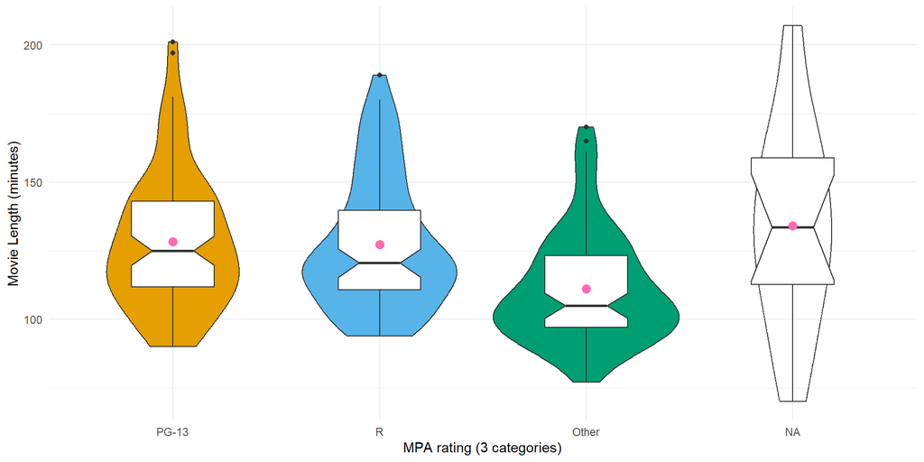

## Second Attempt

Oops. Need to fix missingness.

```r
movies1 <- movies |> filter(complete.cases(mpa3, length))

ggplot(movies1, aes(x = mpa3, y = length)) +
  geom_violin(aes(fill = mpa3)) +
  geom_boxplot(width = 0.4, notch = TRUE) +
  stat_summary(fun = mean, geom = "point", size = 3, col = "hotpink") +
  scale_fill_oi() +
  guides(fill = "none") +
  labs(x = "MPA rating (3 categories)", y = "Movie Length (minutes)")
```

What would we like to see here?

## Second Attempt

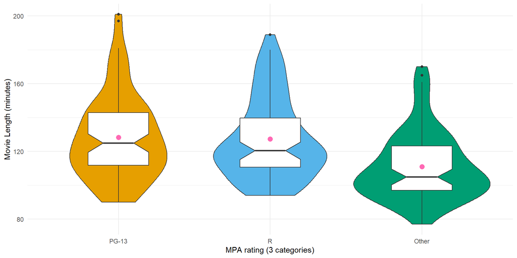

## Comparing 3 means: ANOVA

```r
fit1 <- lm(length ~ mpa3, data = movies)
anova(fit1)
```

```
Analysis of Variance Table

Response: length
           Df Sum Sq Mean Sq F value    Pr(>F)
mpa3        2  15409  7704.4  14.888 7.957e-07 ***
Residuals 243 125751   517.5
---
Signif. codes:  0 '***' 0.001 '**' 0.01 '*' 0.05 '.' 0.1 ' ' 1
```

- The *p* value is 0.0000008. Do we need to say more?
- How much of the variation in `length` does the `fit1` model account for?
  - proportion explained = 15409 / (15409 + 125751) = 0.109

## Parameters of model `fit1`

```r
model_parameters(fit1, ci = 0.98)
```

```
Parameter    | Coefficient |   SE |           98% CI | t(243) |      p
----------------------------------------------------------------------
(Intercept)  |      128.27 | 2.48 | [122.46, 134.09] |  51.68 | < .001
mpa3 [R]     |       -0.96 | 3.55 | [ -9.28,   7.36] |  -0.27 | 0.787
mpa3 [Other] |      -17.24 | 3.53 | [-25.51,  -8.97] |  -4.88 | < .001
```

- What is the regression equation here?
- `length` = 128.27 - 0.96 (if `mpa3` = R) - 17.24 (if `mpa3` = Other)
- Can we estimate the means in each `mpa3` category?

## Predicting for `mpa3` categories?

```r
estimate_means(fit1, ci = 0.98)
```

```
Estimated Marginal Means

mpa3  |   Mean |   SE |           98% CI | t(243)
-------------------------------------------------
PG-13 | 128.27 | 2.48 | [122.46, 134.09] |  51.68
R     | 127.31 | 2.54 | [121.36, 133.27] |  50.06
Other | 111.04 | 2.51 | [105.15, 116.92] |  44.20

Variable predicted: length
Predictors modulated: mpa3
```

- How shall we compare these means and maintain overall 98% confidence?
- Remember the sample sizes: 84 movies in PG-13, 80 in R, 82 in Other.

## Bonferroni comparisons?

```r
PostHocTest(aov(fit1), method = "bonferroni", conf.level = 0.98)
```

```
  Posthoc multiple comparisons of means : Bonferroni
    98% family-wise confidence level

$mpa3
                   diff    lwr.ci    upr.ci    pval
R-PG-13      -0.9613095 -10.68648  8.763859  1.0000
Other-PG-13 -17.2372242 -26.90146 -7.572993 5.7e-06 ***
Other-R     -16.2759146 -26.05877 -6.493064 2.5e-05 ***

---
Signif. codes:  0 '***' 0.001 '**' 0.01 '*' 0.05 '.' 0.1 ' ' 1
```

- What conclusions can we draw?
- Would a Tukey HSD approach be appropriate here?
  - Pre-planned comparisons? (Roughly) balanced design?

## Tukey HSD comparisons

```r
PostHocTest(aov(fit1), method = "hsd", conf.level = 0.98)
```

```
  Posthoc multiple comparisons of means : Tukey HSD
    98% family-wise confidence level

$mpa3
                   diff    lwr.ci    upr.ci    pval
R-PG-13      -0.9613095 -10.57042  8.647799  0.9605
Other-PG-13 -17.2372242 -26.78612 -7.688325 5.7e-06 ***
Other-R     -16.2759146 -25.94202 -6.609812 2.5e-05 ***

---
Signif. codes:  0 '***' 0.001 '**' 0.01 '*' 0.05 '.' 0.1 ' ' 1
```

I like plotting these.

## Plot Tukey HSD results

```r
par(mar=c(3,6,3,3), las = 1)
plot(PostHocTest(aov(fit1), method = "hsd", conf.level = 0.98))
```

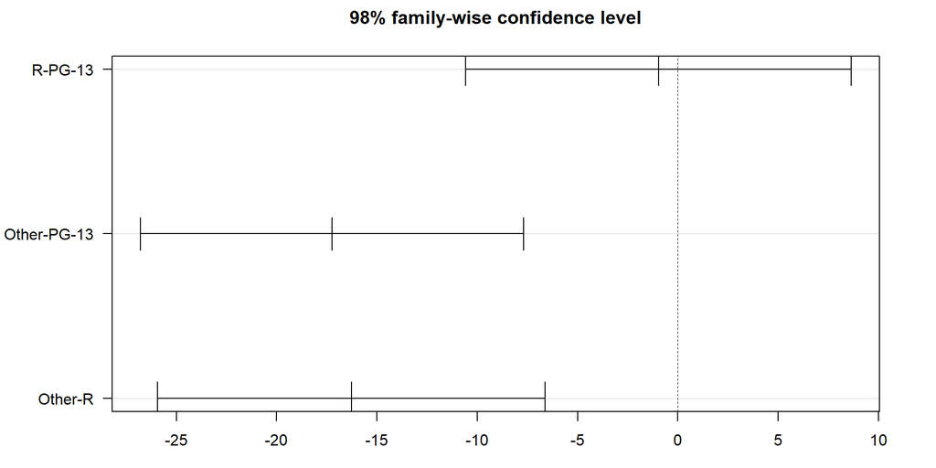

## Check ANOVA diagnostics

```r
set.seed(123)
plot(check_model(fit1, check = c("pp_check", "qq"), detrend = FALSE))
```

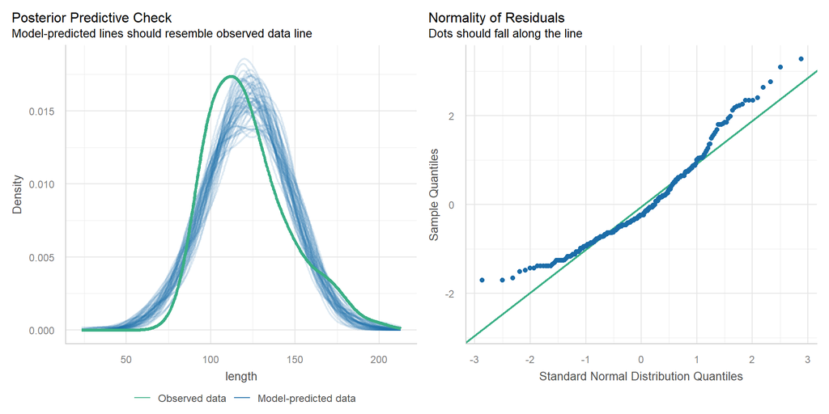

## Would a transformation help?

```r
boxCox(fit1)
```

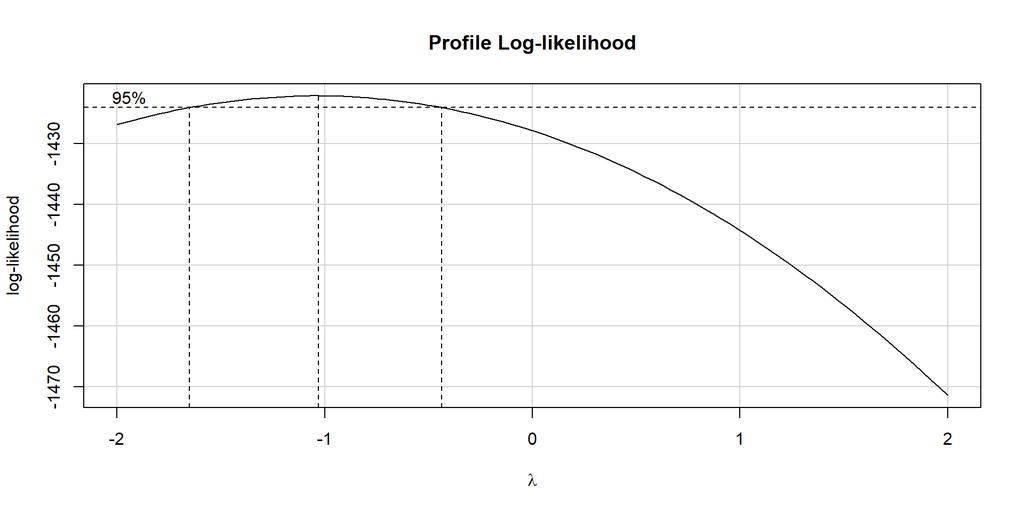

## Inverse of our outcome

```r
movies1 <- movies1 |> mutate(invlength = 1000/length)

fit1a <- lm(invlength ~ mpa3, data = movies1)
anova(fit1a)
```

```
Analysis of Variance Table

Response: invlength
           Df Sum Sq Mean Sq F value    Pr(>F)
mpa3        2  75.88  37.940  18.215 4.255e-08 ***
Residuals 243 506.13   2.083
---
Signif. codes:  0 '***' 0.001 '**' 0.01 '*' 0.05 '.' 0.1 ' ' 1
```

## Why did I use 1000/length?

```r
movies1 <- movies1 |> mutate(length_inv = 1/length)

fit1b <- lm(length_inv ~ mpa3, data = movies1)
anova(fit1b)
```

```
Analysis of Variance Table

Response: length_inv
           Df     Sum Sq   Mean Sq F value    Pr(>F)
mpa3        2 0.00007588 3.794e-05  18.215 4.255e-08 ***
Residuals 243 0.00050613 2.083e-06
---
Signif. codes:  0 '***' 0.001 '**' 0.01 '*' 0.05 '.' 0.1 ' ' 1
```

## ANOVA diagnostics better?

```r
set.seed(124)
plot(check_model(fit1a, check = c("pp_check", "qq"), detrend = FALSE))
```

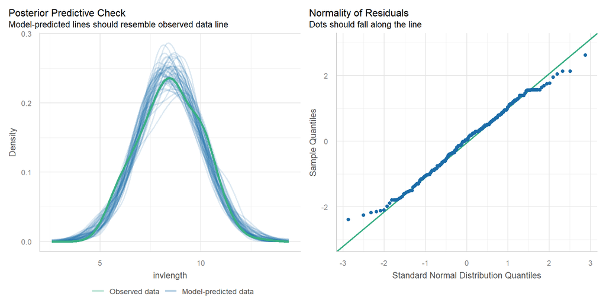

## Estimate group means from `fit1a`

```r
estimate_means(fit1a, ci = 0.98)
```

```
Estimated Marginal Means

mpa3  | Mean |   SE |       98% CI | t(243)
-------------------------------------------
PG-13 | 8.06 | 0.16 | [7.69, 8.43] |  51.20
R     | 8.11 | 0.16 | [7.73, 8.48] |  50.23
Other | 9.26 | 0.16 | [8.89, 9.63] |  58.11

Variable predicted: invlength
Predictors modulated: mpa3
```

- What does a predicted (1000/length) of 8.11 mean?
- Back out of transformation…
  - if 1000/length = 8.11, then length = 1000/8.11 = 123.3 minutes (compare to 127.31 in untransformed data.)

## Tukey HSD for `fit1a` model

```r
par(mar=c(3,6,3,3), las = 1)
plot(PostHocTest(aov(fit1a), method = "hsd", conf.level = 0.98))
```

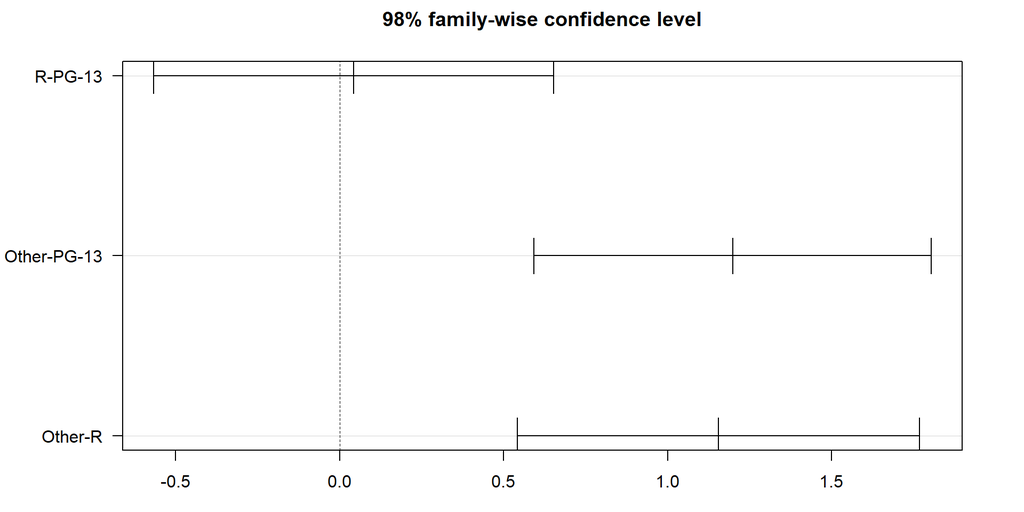

## Why did the direction change?

```r
PostHocTest(aov(fit1a), method = "hsd", conf.level = 0.98)
```

```
  Posthoc multiple comparisons of means : Tukey HSD
    98% family-wise confidence level

$mpa3
                  diff     lwr.ci    upr.ci    pval
R-PG-13     0.04270197 -0.5669202 0.6523241  0.9804
Other-PG-13 1.19840071  0.5925984 1.8042030 6.1e-07 ***
Other-R     1.15569874  0.5424608 1.7689367 2.1e-06 ***

---
Signif. codes:  0 '***' 0.001 '**' 0.01 '*' 0.05 '.' 0.1 ' ' 1
```

- PG-13 and R movies still look longer than “Other”
- but a longer movie has a smaller **1000/length** value.

# Question 2

## Question 2

How well can we predict `imdb_stars` (the public: 0-10 scale) using `metascore` (critics: 0-100 scale)?

```r
ggplot(movies, aes(x = metascore, y = imdb_stars)) +
  geom_point() +
  geom_smooth(method = "lm", col = "red", formula = y ~ x, se = TRUE) +
  geom_smooth(method = "loess", col = "blue", formula = y ~ x, se = FALSE) +
  labs(x = "Metascore from Critics", y = "Average IMDB Star Rating")
```

## Question 2

[figure not shown]

## Deal with missing values

```r
movies2 <- movies |>
  select(mov_id, metascore, imdb_stars, imdb_genres, movie) |>
  filter(complete.cases(metascore, imdb_stars))

ggplot(movies2, aes(x = metascore, y = imdb_stars)) +
  geom_point() +
  geom_smooth(method = "lm", col = "red", formula = y ~ x, se = TRUE) +
  geom_smooth(method = "loess", col = "blue", formula = y ~ x, se = FALSE) +
  labs(x = "Metascore from Critics", y = "Average IMDB Star Rating")
```

## Deal with missing values

[figure not shown]

## Which movies have low `imdb_stars`?

```r
ggplot(movies2, aes(x = metascore, y = imdb_stars)) +
  geom_point() +
  geom_label(data = movies2 |> filter(imdb_stars < 5.5), aes(label = movie))
```

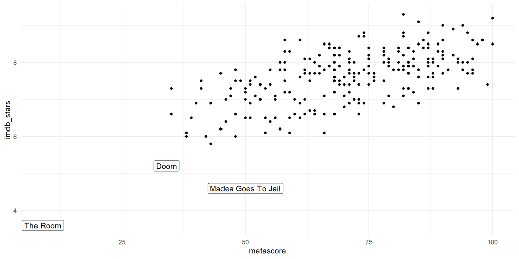

## Which three movies are those?

```r
movies2 |> filter(imdb_stars < 5.5) |>
  select(mov_id, imdb_stars, metascore, movie, imdb_genres)
```

```
# A tibble: 3 × 5
  mov_id imdb_stars metascore movie              imdb_genres
  <chr>       <dbl>     <dbl> <chr>              <fct>
1 M-152         4.6        50 Madea Goes To Jail Comedy, Crime, Drama
2 M-058         5.2        34 Doom               Action, Horror, Sci-Fi
3 M-211         3.6         9 The Room           Drama
```

Let’s keep these movies in, for now, at least.

## Anything else need attention?

```r
data_codebook(movies2 |> select(metascore, imdb_stars))
```

```
select(movies2, metascore, imdb_stars) (245 rows and 2 variables, 2 shown)

ID | Name       | Type    | Missings |     Values |   N
---+------------+---------+----------+------------+----
1  | metascore  | numeric | 0 (0.0%) |   [9, 100] | 245
---+------------+---------+----------+------------+----
2  | imdb_stars | numeric | 0 (0.0%) | [3.6, 9.3] | 245
-------------------------------------------------------
```

```r
movies2 |> reframe(lovedist(imdb_stars))
```

```
# A tibble: 1 × 10
      n  miss  mean    sd   med   mad   min   q25   q75   max
  <int> <int> <dbl> <dbl> <dbl> <dbl> <dbl> <dbl> <dbl> <dbl>
1   245     0  7.61 0.781   7.7 0.741   3.6   7.2   8.1   9.3
```

```r
movies2 |> reframe(lovedist(metascore))
```

```
# A tibble: 1 × 10
      n  miss  mean    sd   med   mad   min   q25   q75   max
  <int> <int> <dbl> <dbl> <dbl> <dbl> <dbl> <dbl> <dbl> <dbl>
1   245     0  70.8  15.8    71  17.8     9    60    83   100
```

## Linear model, fit with OLS

Predict `imdb_stars` using `metascore` using OLS.

```r
fit2 <- lm(imdb_stars ~ metascore, data = movies2)

## We'll use 89% confidence here, just for fun.
model_parameters(fit2, digits = 3, ci = 0.89)
```

```
Parameter   | Coefficient |    SE |         89% CI | t(243) |      p
--------------------------------------------------------------------
(Intercept) |       5.370 | 0.177 | [5.085, 5.655] | 30.266 | < .001
metascore   |       0.032 | 0.002 | [0.028, 0.036] | 12.931 | < .001
```

- What is our `fit2` model’s regression equation?
- `imdb_stars` = 5.37 + 0.032 `metascore`
- Does the intercept (5.37) mean anything to us here?

## Interpreting the coefficients

```r
model_parameters(fit2, digits = 3, ci = 0.89)
```

```
Parameter   | Coefficient |    SE |         89% CI | t(243) |      p
--------------------------------------------------------------------
(Intercept) |       5.370 | 0.177 | [5.085, 5.655] | 30.266 | < .001
metascore   |       0.032 | 0.002 | [0.028, 0.036] | 12.931 | < .001
```

- If we have two movies, and movie A has a `metascore` that is 1 point higher than movie B, then …
- our model `fit2` predicts that movie A will have an `imdb_stars` value that is 0.032 higher than movie B.
- What if movie A’s metascore was 10 points higher than movie B’s?

## Making Predictions with `fit2`

```r
dat_new <- tibble(metascore = c(10, 20, 30, 40, 41))
estimate_prediction(fit2, data = dat_new, ci = 0.89)
```

```
Model-based Predictions

metascore | Predicted |   SE |       89% CI
-------------------------------------------
10        |      5.69 | 0.62 | [4.69, 6.68]
20        |      6.00 | 0.62 | [5.01, 6.99]
30        |      6.32 | 0.61 | [5.34, 7.30]
40        |      6.64 | 0.61 | [5.66, 7.61]
41        |      6.67 | 0.61 | [5.69, 7.64]

Variable predicted: imdb_stars
```

- Could instead use `estimate_expectation()`: same predictions, just confidence intervals rather than prediction intervals.

## Does the model perform well?

```r
model_performance(fit2)
```

```
# Indices of model performance

AIC   |  AICc |   BIC |    R2 | R2 (adj.) |  RMSE | Sigma
---------------------------------------------------------
451.0 | 451.1 | 461.5 | 0.408 |     0.405 | 0.600 | 0.603
```

- How can we interpret `Sigma` = 0.603?
  - About 95% of our predicted `imdb_stars` should be within $\pm 2(0.603)$ stars. Is this good?
  - `movies2` data: `imdb_stars`: range (3.6, 9.3), sd = 0.781.
  - IQR (middle half of movies) are between 7.2 and 8.1

## Thinking about R-square

```r
model_performance(fit2)
```

```
# Indices of model performance

AIC   |  AICc |   BIC |    R2 | R2 (adj.) |  RMSE | Sigma
---------------------------------------------------------
451.0 | 451.1 | 461.5 | 0.408 |     0.405 | 0.600 | 0.603
```

- What proportion of the variation in `imdb_stars` is explained by `metascore`?
- R-square = 0.408. So what is the Pearson correlation?
- Same sign as slope: `imdb_stars` = 5.37 + 0.032 `metascore`
- Square root of R-square (0.408) is 0.639.

## Checking OLS Model Fit

Main assumptions of any simple linear regression are:

1. **linearity**: we assume that the outcome is linearly related to our predictor
2. **constant variance** (homoscedasticity): we assume that the variation of our outcome is about the same regardless of the value of our predictor
3. **normal distribution**: we assume that the errors around the regression model at any specified values of the x-variables follow an approximately Normal distribution.

To check these assumptions, consider the following plots.

## Diagnostic Plots?

For an HTML report, run this, with

`#| fig-height: 8` in the first line of the code chunk, then

```r
set.seed(12345)
plot(check_model(fit2, detrend = FALSE))
```

but for the slides, I’ll do…

```r
set.seed(12345)
fit2_dx <- plot(check_model(fit2, detrend = FALSE, panel = FALSE))
```

so I can show each plots in a separate slide.

- `set.seed()` is so we all get the same posterior predictive plot.

## Posterior Predictive Check

```r
fit2_dx[[1]]
```

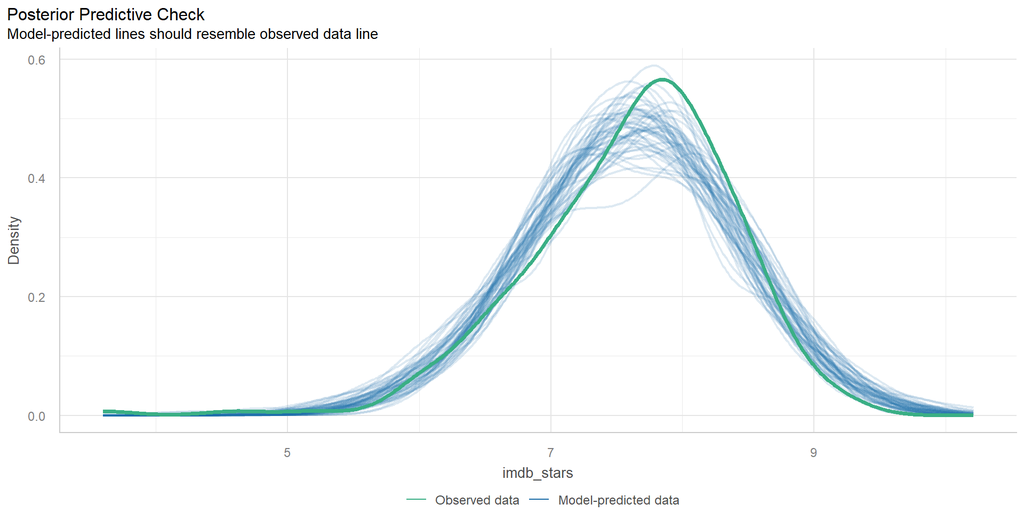

## Linearity Plot

```r
fit2_dx[[2]]
```

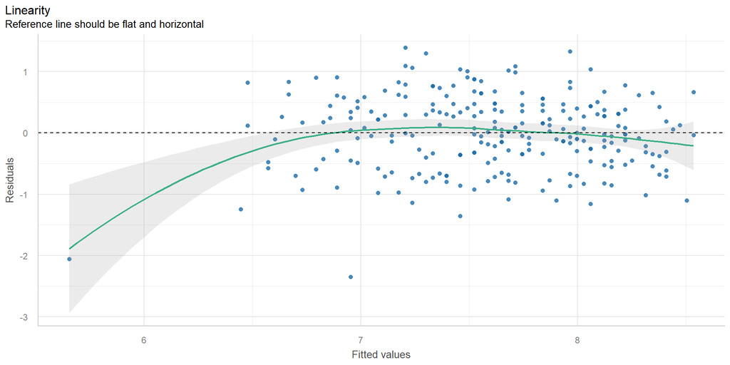

## Homogeneity of Variance Plot

```r
fit2_dx[[3]]
```

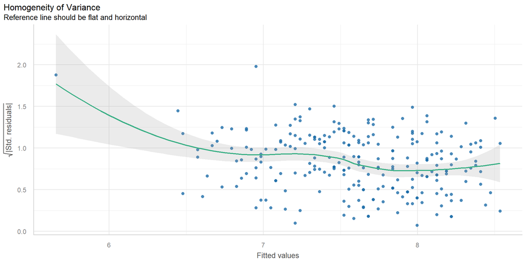

## Influential Observations

```r
fit2_dx[[4]]
```

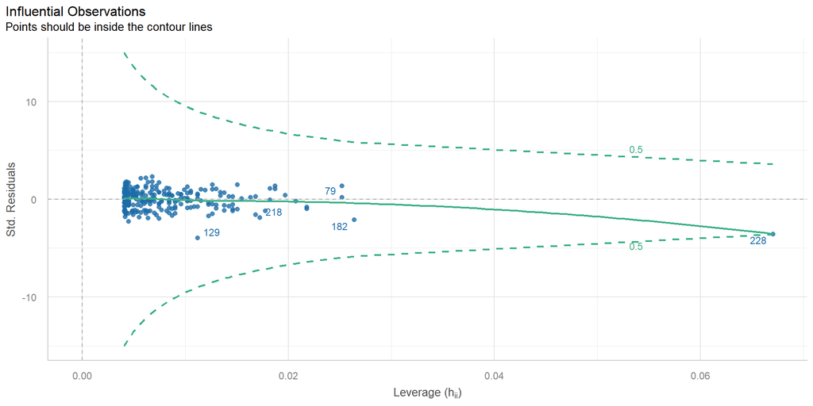

## What is point 228?

```r
movies2 |> slice(228) |>
  select(mov_id, metascore, imdb_stars, movie)
```

```
# A tibble: 1 × 4
  mov_id metascore imdb_stars movie
  <chr>      <dbl>      <dbl> <chr>
1 M-211          9        3.6 The Room
```

- If we removed “The Room”, we would see some changes in our model.
- “The Room” is the movie with the lowest `metascore`, and the lowest `imdb_stars` of any of our movies.

## Normality of Residuals

```r
fit2_dx[[5]]
```

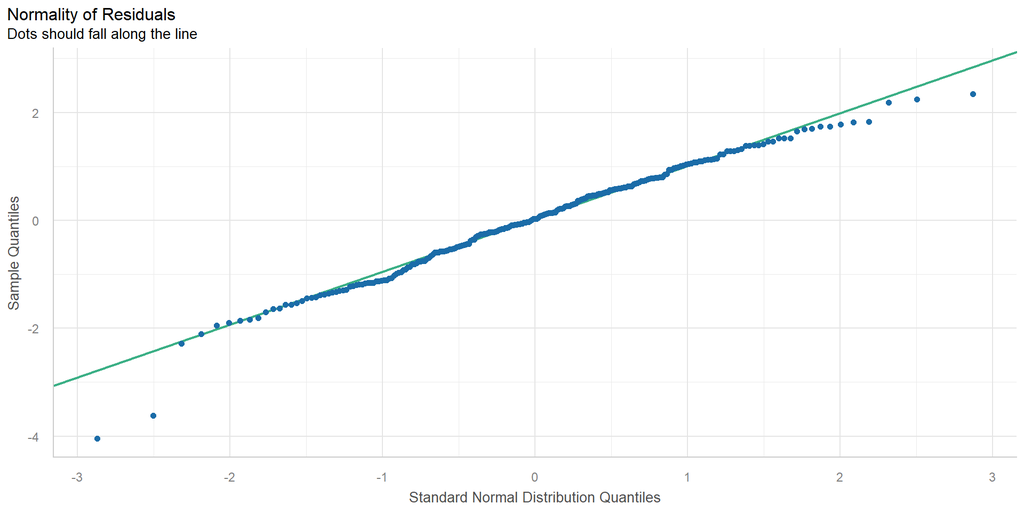

## Which movies are poorly fit?

```r
movies2 <- movies2 |> mutate(residf2 = resid(fit2), fitf2 = fitted(fit2))
ggplot(movies2, aes(x = residf2)) +
  geom_histogram(bins = 25, fill = "navy", col = "white")
```

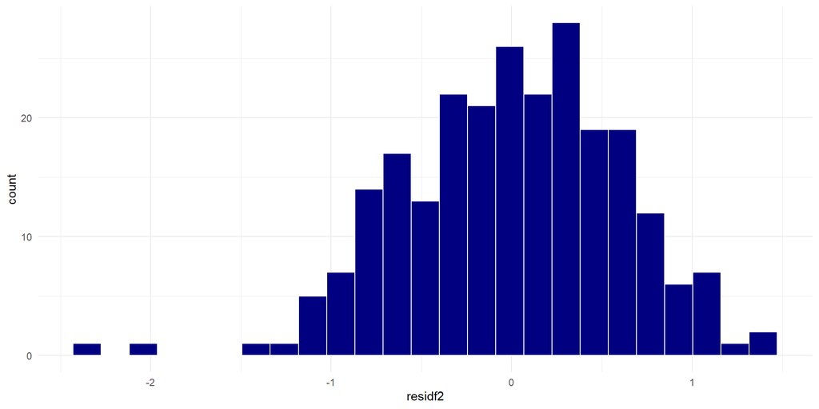

## Which movies miss the mark?

Which movies are more than 1.2 stars off in their predictions?

```r
movies2 |> filter(residf2 < -1.2 | residf2 > 1.2) |>
  select(mov_id, metascore, imdb_stars, movie, residf2, fitf2) |>
  arrange(residf2)
```

```
# A tibble: 7 × 6
  mov_id metascore imdb_stars movie                    residf2 fitf2
  <chr>      <dbl>      <dbl> <chr>                      <dbl> <dbl>
1 M-152         50        4.6 Madea Goes To Jail         -2.35  6.95
2 M-211          9        3.6 The Room                   -2.05  5.65
3 M-174         66        6.1 Mystery Men                -1.36  7.46
4 M-058         34        5.2 Doom                       -1.25  6.45
5 M-092         61        8.6 The Green Mile              1.30  7.30
6 M-219         82        9.3 The Shawshank Redemption    1.33  7.97
7 M-138         58        8.6 Life Is Beautiful           1.39  7.21
```

## Regression Model Calibration?

```r
ggplot(movies2, aes(x = imdb_stars, y = fitf2)) +
  geom_text(aes(label = mov_id)) +
  geom_abline( slope = 1, intercept = 0 , col = "sienna", lwd = 2)
```

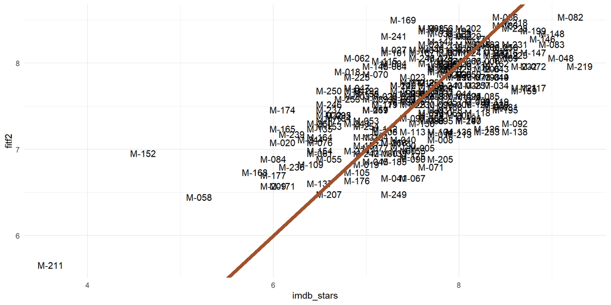

## Calibration of this Model?

```r
ggplot(movies2, aes(x = imdb_stars, y = fitf2)) +
  geom_point() +
  geom_label(data = movies2 |> filter(imdb_stars < 5.4), aes(label = movie)) +
  geom_abline( slope = 1, intercept = 0 , col = "sienna", lwd = 2)
```

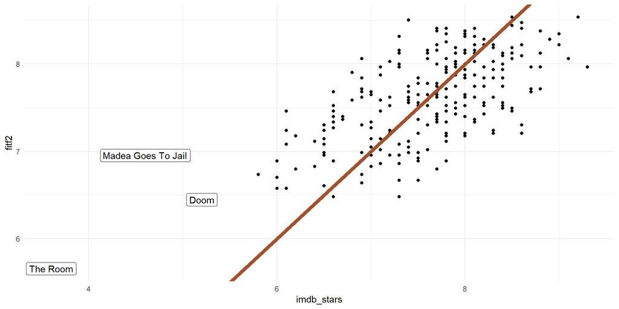

## What if we dropped the three outliers?

We’d have to have a real reason to do this, of course. It couldn’t just be “our model doesn’t fit them well.”

```r
movies2a <- movies2 |> filter(imdb_stars >= 5.5)

dim(movies2)
```

```
[1] 245   7
```

```r
dim(movies2a)
```

```
[1] 242   7
```

## Scatterplot with and without

What happens when we drop our three “outliers”?

```r
p1 <- ggplot(movies2, aes(x = metascore, y = imdb_stars)) +
  geom_point() +
  geom_smooth(method = "lm", col = "red", formula = y ~ x, se = TRUE) +
  geom_smooth(method = "loess", col = "blue", formula = y ~ x, se = FALSE) +
  labs(x = "Metascore from Critics", y = "Average IMDB Star Rating",
       title = "245 Movies")

p2 <- ggplot(movies2a, aes(x = metascore, y = imdb_stars)) +
  geom_point() +
  geom_smooth(method = "lm", col = "red", formula = y ~ x, se = TRUE) +
  geom_smooth(method = "loess", col = "blue", formula = y ~ x, se = FALSE) +
  labs(x = "Metascore from Critics", y = "Average IMDB Star Rating",
       title = "242 Movies")

p1 + p2
```

## Scatterplot with and without

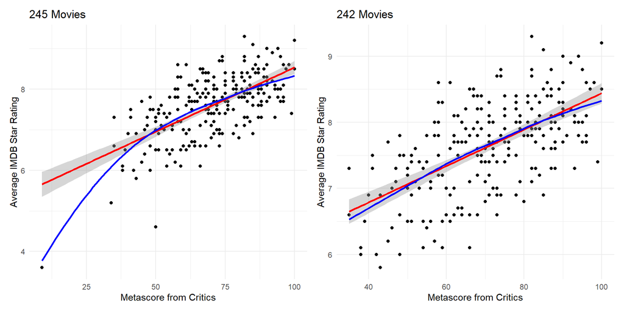

## With and without 3 movies

```r
## with Madea Goes to Jail, Doom, and The Room
model_parameters(fit2, ci = 0.89)
```

```
Parameter   | Coefficient |       SE |       89% CI | t(243) |      p
---------------------------------------------------------------------
(Intercept) |        5.37 |     0.18 | [5.09, 5.65] |  30.27 | < .001
metascore   |        0.03 | 2.45e-03 | [0.03, 0.04] |  12.93 | < .001
```

```r
## without those movies
fit2a <- lm(imdb_stars ~ metascore, data = movies2a)
model_parameters(fit2a, ci = 0.89)
```

```
Parameter   | Coefficient |       SE |       89% CI | t(240) |      p
---------------------------------------------------------------------
(Intercept) |        5.68 |     0.17 | [5.40, 5.96] |  32.54 | < .001
metascore   |        0.03 | 2.40e-03 | [0.02, 0.03] |  11.49 | < .001
```

## With and without 3 movies

Summaries aren’t directly comparable, since we’ve dropped three movies.

```r
## with Madea Goes to Jail, Doom, and The Room
model_performance(fit2, ci = 0.89)
```

```
# Indices of model performance

AIC   |  AICc |   BIC |    R2 | R2 (adj.) |  RMSE | Sigma
---------------------------------------------------------
451.0 | 451.1 | 461.5 | 0.408 |     0.405 | 0.600 | 0.603
```

```r
## without those movies
model_performance(fit2a, ci = 0.89)
```

```
# Indices of model performance

AIC   |  AICc |   BIC |    R2 | R2 (adj.) |  RMSE | Sigma
---------------------------------------------------------
412.0 | 412.1 | 422.5 | 0.355 |     0.352 | 0.560 | 0.562
```

## Prediction if `metascore` is 60

```r
dat_new2 <- tibble(metascore = 60)

## with Madea Goes to Jail, Doom, and The Room
estimate_expectation(fit2, ci = 0.89, data = dat_new2)
```

```
Model-based Predictions

metascore | Predicted |   SE |       89% CI
-------------------------------------------
60        |      7.27 | 0.05 | [7.19, 7.34]

Variable predicted: imdb_stars
```

```r
## without those movies
estimate_expectation(fit2a, ci = 0.89, data = dat_new2)
```

```
Model-based Predictions

metascore | Predicted |   SE |       89% CI
-------------------------------------------
60        |      7.34 | 0.05 | [7.27, 7.41]

Variable predicted: imdb_stars
```

## Are the diagnostic plots better?

```r
set.seed(12121)
fit2a_dx <- plot(check_model(fit2a, detrend = FALSE, panel = FALSE))
```

## “With” on left, “Without” on right

```r
p1 <- fit2_dx[[1]]
p2 <- fit2a_dx[[1]]
p1 + p2
```

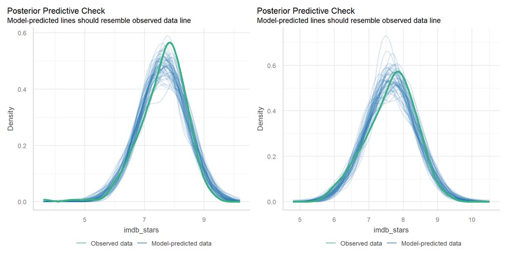

## “With” on left, “Without” on right

```r
p1 <- fit2_dx[[2]]
p2 <- fit2a_dx[[2]]
p1 + p2
```

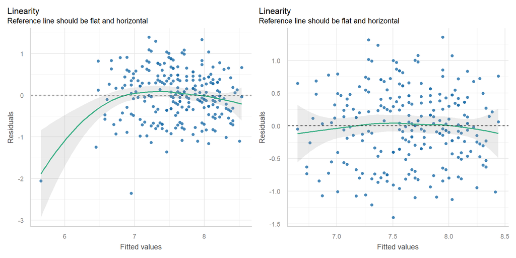

## “With” on left, “Without” on right

```r
p1 <- fit2_dx[[3]]
p2 <- fit2a_dx[[3]]
p1 + p2
```

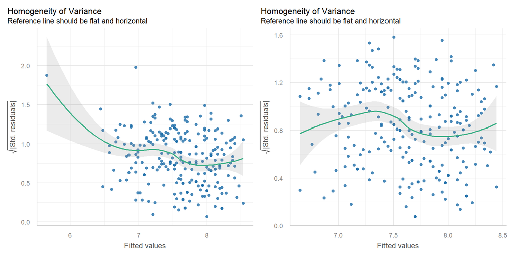

## “With” on left, “Without” on right

```r
p1 <- fit2_dx[[4]]
p2 <- fit2a_dx[[4]]
p1 + p2
```

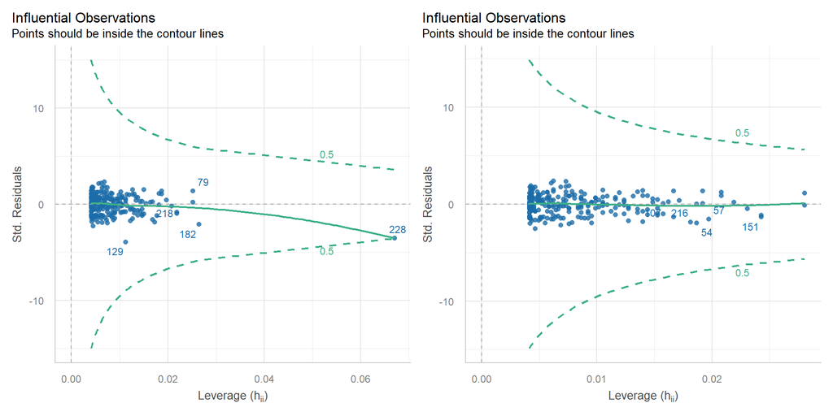

## “With” on left, “Without” on right

```r
p1 <- fit2_dx[[5]]
p2 <- fit2a_dx[[5]]
p1 + p2
```

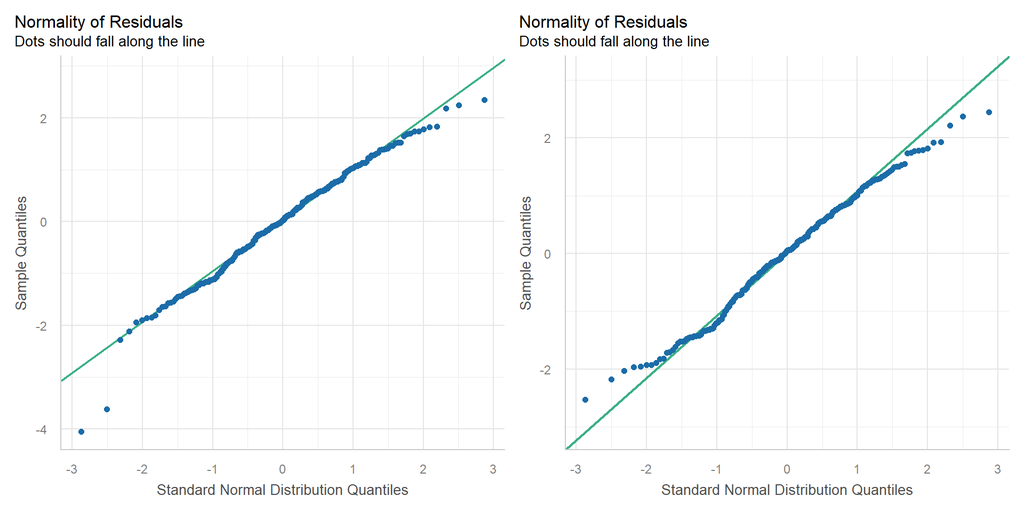